```r
library(designit)
library(ggplot2)
library(dplyr)
library(tidyr)
```

# Example 2: Scoring two plates at once

(latin square for each plate should give the best score)

We set up in one go 2 plate scoring functions, each one acting locally on a specific plate, plus one osat score to guarantee uniform distribution of groups across plates.

The initial sample allocation (by assign_in_order) leads to a poor starting point since each plate has only 2 of the 4 groups represented.

This is not a problem as long as we make sure that initial permutations are likely to remedy the situation. That’s why we ensure 10 pairwise sample swaps for the first iterations.

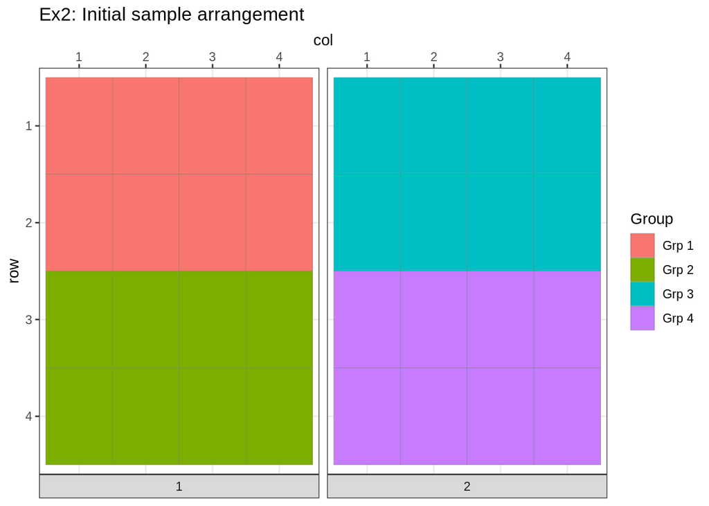

```r
# Setting up the batch container
example2 <- BatchContainer$new(
  dimensions = c(
    plate = 2,
    row = 4, col = 4
  )
)

# Add samples to container
example2 <- assign_in_order(example2, samples = tibble::tibble(
  Group = c(rep(c("Grp 1", "Grp 2", "Grp 3", "Grp 4"), each = 8)),
  ID = 1:32
))

scoring_f <- c(mk_plate_scoring_functions(example2, plate = "plate", row = "row", column = "col", group = "Group"),
  osat_plate = osat_score_generator(batch_vars = c("plate"), feature_vars = c("Group"))
)

plot_plate(example2,
  plate = plate, row = row, column = col, .color = Group,
  title = "Ex2: Initial sample arrangement"
)
```

```r
example2$score(scoring_f)
```

```
#>    Plate 1    Plate 2 osat_plate
#>   23.89265   23.89265  128.00000
```

```r
set.seed(41)
bc <- optimize_design(
  example2,
  scoring = scoring_f,
  n_shuffle = c(rep(10, 10), rep(3, 90), rep(2, 100), rep(1, 1400)),
  acceptance_func = mk_simanneal_acceptance_func(mk_simanneal_temp_func(T0 = 10000, alpha = 0.5)),
  aggregate_scores_func = worst_score,
  quiet = TRUE
)
```

```r
bc$trace$elapsed
```

```
#> Time difference of 13.84524 secs
```

```r
bc$score(scoring_f)
```

```
#>    Plate 1    Plate 2 osat_plate
#>   6.127258   6.094080   0.000000
```

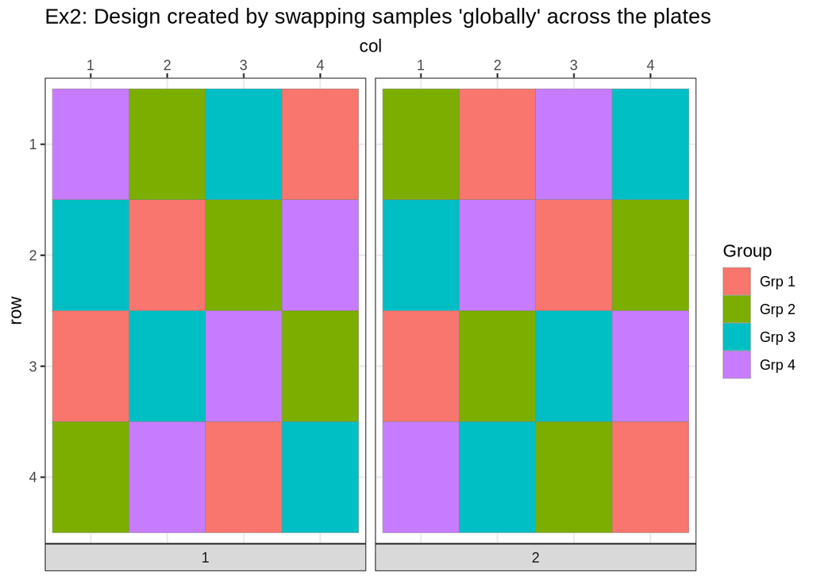

```r
plot_plate(bc,
  plate = plate, row = row, column = col, .color = Group,
  title = "Ex2: Design created by swapping samples 'globally' across the plates"
)
```

While this ‘global’ optimization is possible, it does probably not converge to an (almost) ideal solution in an acceptable time if there are more samples involved. This is due to a lot of unproductive sample swapping happening across the plates.

One way to address this: we may split the optimization into two cycles, first assigning samples to plates (balancing groups), then improving the positions of the samples within each plate. This motivates the use of a dedicated sample permutation function which takes the plate structure into account and only shuffles samples around within one plate.

```r
scoring_f <- osat_score_generator(batch_vars = c("plate"), feature_vars = c("Group"))

set.seed(42)
bc <- optimize_design(
  example2,
  scoring = scoring_f,
  quiet = TRUE,
  max_iter = 200, # this is set to shorten vignette run-time, normally we don't know.
  n_shuffle = 2,
  acceptance_func = mk_simanneal_acceptance_func(mk_simanneal_temp_func(T0 = 10000, alpha = 0.5)),
)
bc$trace$elapsed
```

```
#> Time difference of 1.634799 secs
```

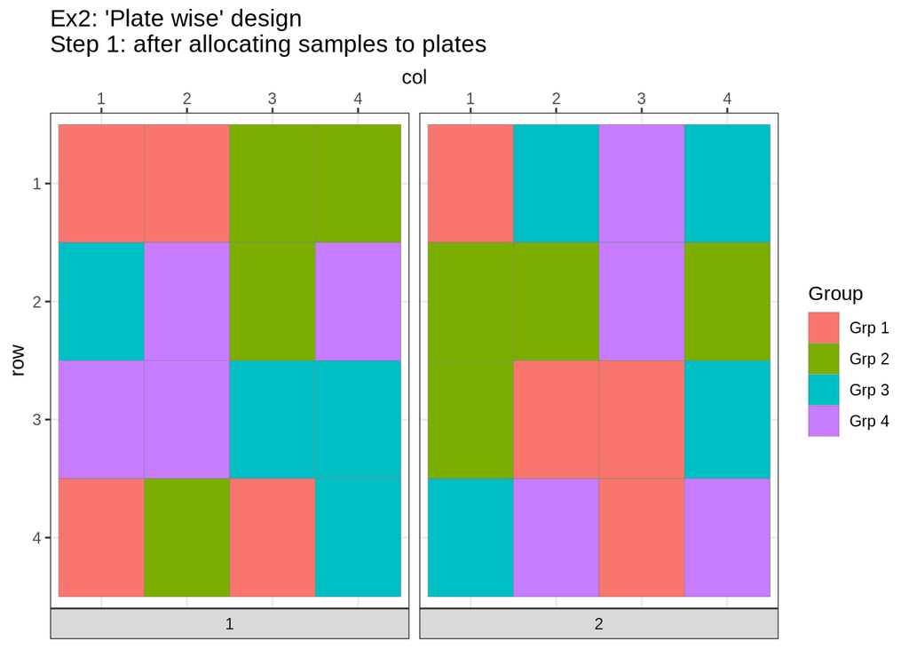

```r
plot_plate(bc,
  plate = plate, row = row, column = col, .color = Group,
  title = "Ex2: 'Plate wise' design\nStep 1: after allocating samples to plates"
)
```

```r
scoring_f <- mk_plate_scoring_functions(bc, plate = "plate", row = "row", column = "col", group = "Group")

bc$score(scoring_f)
```

```
#>  Plate 1  Plate 2
#> 12.77527 13.63704
```

```r
set.seed(42)
bc <- optimize_design(
  bc,
  scoring = scoring_f,
  max_iter = 400,
  shuffle_proposal_func = mk_subgroup_shuffling_function(subgroup_vars = c("plate")),
  acceptance_func = mk_simanneal_acceptance_func(mk_simanneal_temp_func(T0 = 1000, alpha = 0.5)),
  aggregate_scores_func = L2s_norm,
  quiet = TRUE
)
```

```r
bc$trace$elapsed
```

```
#> Time differences in secs
#> [1] 1.634799 2.326842
```

```r
bc$score(scoring_f)
```

```
#>  Plate 1  Plate 2
#> 6.854748 6.309297
```

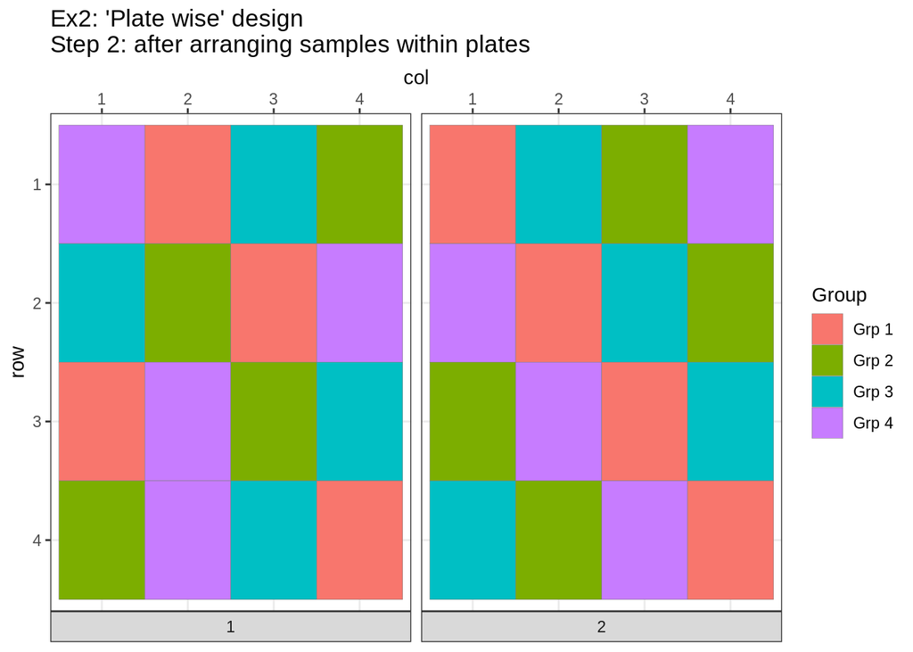

```r
plot_plate(bc,
  plate = plate, row = row, column = col, .color = Group,
  title = "Ex2: 'Plate wise' design\nStep 2: after arranging samples within plates"
)
```

In this case, the shuffling function exchanges 1 pair of sample assignments every time (the default). However, any number of constant swaps or a swapping protocol (formally a vector of integers) can be supplied as well.

```r
scoring_f <- osat_score_generator(batch_vars = c("plate"), feature_vars = c("Group"))
```

```r
set.seed(42)
bc <- optimize_design(
  example2,
  scoring = scoring_f,
  quiet = TRUE,
  max_iter = 150, # this is set to shorten vignette run-time, normally we don't know.
  n_shuffle = 2,
  acceptance_func = mk_simanneal_acceptance_func(mk_simanneal_temp_func(T0 = 10000, alpha = 0.5)),
)
```

```r
bc$trace$elapsed
```

```
#> Time difference of 1.372123 secs
```

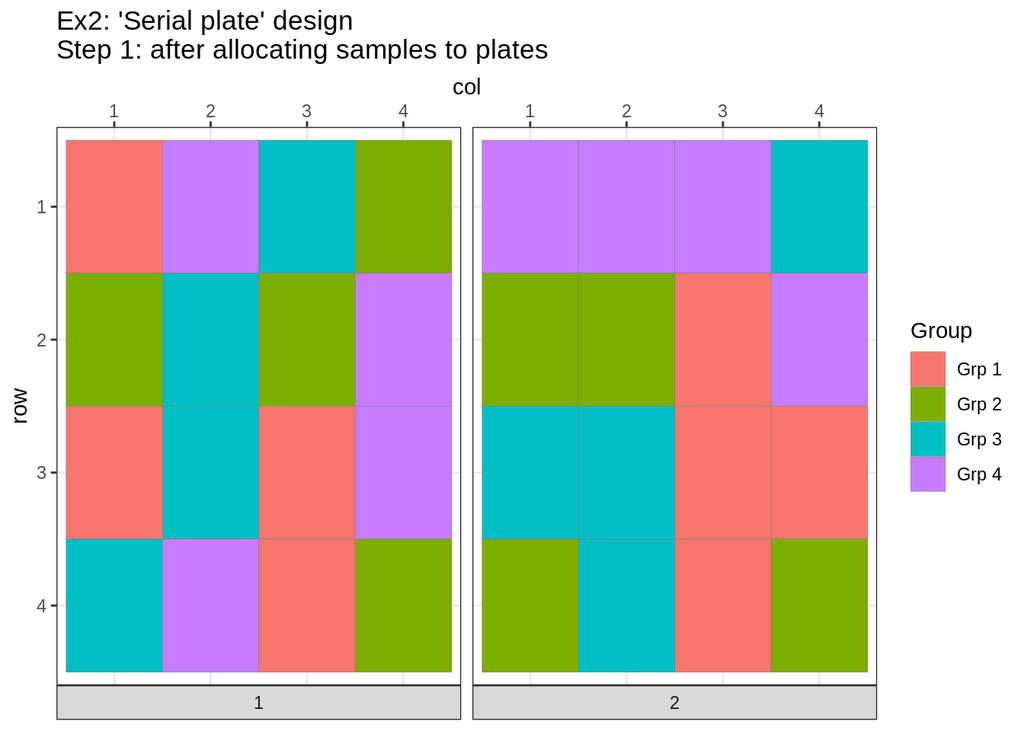

```r
plot_plate(bc,
  plate = plate, row = row, column = col, .color = Group,
  title = "Ex2: 'Serial plate' design\nStep 1: after allocating samples to plates"
)
```

```r
scoring_f <- mk_plate_scoring_functions(bc, plate = "plate", row = "row", column = "col", group = "Group")

bc$score(scoring_f)
```

```
#>  Plate 1  Plate 2
#> 10.57482 26.16613
```

```r
set.seed(42)
bc <- optimize_design(
  bc,
  scoring = scoring_f,
  max_iter = 150,
  quiet = TRUE,
  shuffle_proposal_func = mk_subgroup_shuffling_function(subgroup_vars = c("plate"), restrain_on_subgroup_levels = c(1)),
  acceptance_func = mk_simanneal_acceptance_func(mk_simanneal_temp_func(T0 = 1000, alpha = 0.5)),
  aggregate_scores_func = L2s_norm
)
```

```r
bc$trace$elapsed
```

```
#> Time differences in secs
#> [1] 1.372123 1.127218
```

```r
bc$score(scoring_f)
```

```
#>   Plate 1   Plate 2
#>  6.416193 26.166134
```

```r
set.seed(42)
bc <- optimize_design(
  bc,
  scoring = scoring_f,
  max_iter = 550,
  quiet = TRUE,
  shuffle_proposal_func = mk_subgroup_shuffling_function(subgroup_vars = c("plate"), restrain_on_subgroup_levels = c(2)),
  acceptance_func = mk_simanneal_acceptance_func(mk_simanneal_temp_func(T0 = 1000, alpha = 0.5)),
  aggregate_scores_func = L2s_norm
)
```

```r
bc$trace$elapsed
```

```
#> Time differences in secs
#> [1] 1.372123 1.127218 3.161646
```

```r
bc$score(scoring_f)
```

```
#>  Plate 1  Plate 2
#> 6.416193 6.581966
```

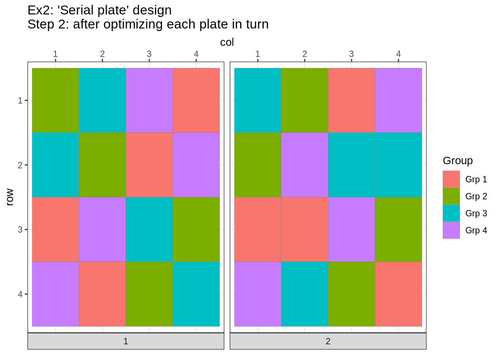

```r
plot_plate(bc,
  plate = plate, row = row, column = col, .color = Group,
  title = "Ex2: 'Serial plate' design\nStep 2: after optimizing each plate in turn"
)
```